# Car Sales Prediction

James(Changhwan) Han (3923257)

12/2/2022

```r
# Required Library
library(MASS)
library(forecast)
library(qpcR)
library(ggplot2)
library(ldsr) # perform inverse Box-Cox transform
```

# Table Of content

1. Abstract
2. Introduction
3. Sections
4. Conclusion
5. Reference
6. Appendix

## Abstract

The “New Car Sales in Norway” dataset describes monthly car sales between 2007 and 2016. As an international student who flies back to my country a lot, I noticed that the prices for flight were way more expensive in certain months. And I was curious if car sales have some logic in it. “Are cars more expensive in certain months?”  
In order to validate my assumption I used time series including transforming data and make a model to predict future car sales. From the prediction, I couldn’t find any differences between months but it would give us better insights with having more datasets.

## Sections

### Car Sales Data

```r
# load data
cars <- scan("norway_new_car_sales_by_month.txt")
```

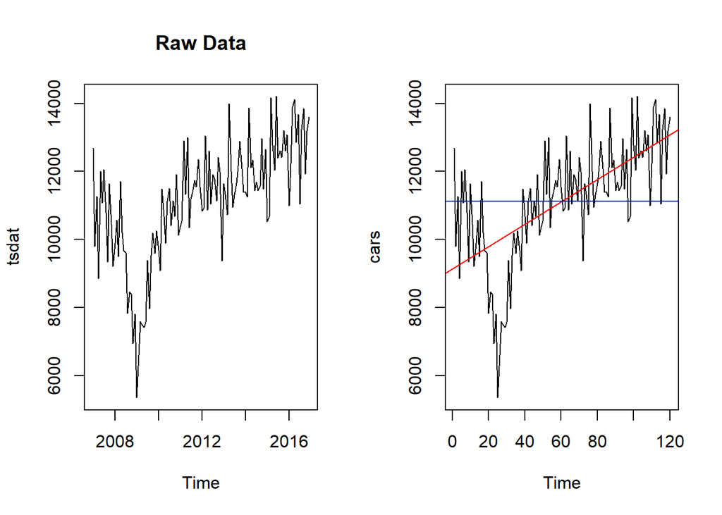

```r
par(mfrow=c(1,2))

# plot of data with years on x-axis
tsdat <- ts(cars, start = c(2007,1), end = c(2016,12), frequency = 12)

ts.plot(tsdat, main = "Raw Data")

# plot of data with time on x-axis
plot.ts(cars)

fit <- lm(cars ~ as.numeric(1:length(cars)))
# plot trend
abline(fit,col="red")
# plot mean
abline(h=mean(cars), col="blue")
```

Two plots represent car sales having year and time on x-axis respectively. From January 2007 to December 2016, there are 120 observations.

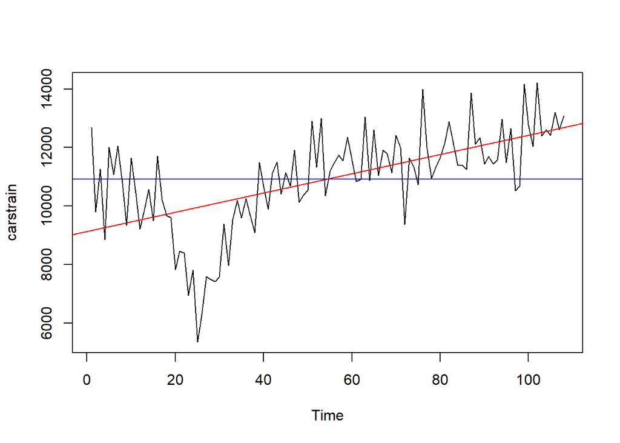

```r
# split the model : train/test
# we are going to work with carstrain , {U_t, t=1,2,...,120}
# we check validity of the model with cars.test
carstrain = cars[c(1:108)]
cars.test = cars[(c(109:120))]

# plot train set of the model
plot.ts(carstrain)

fit <- lm(carstrain~ as.numeric(1:length(carstrain)))

# plot trend and mean respectively
abline(fit, col="red")
abline(h=mean(carstrain), col="blue")
```

Since I do not have any new data and to check validity of the model I create, I started with creating a test/train set. Train set corresponds to 108 observations of the first 9 years and test set corresponds to the 12 observations of the last year, 2016. I am going to use the trainset to build a model throughout the project.  
There doesn’t seem to be a seasonality and there is a downward trend in the beginning. However, after that, I was able to see upward trend in car sales.

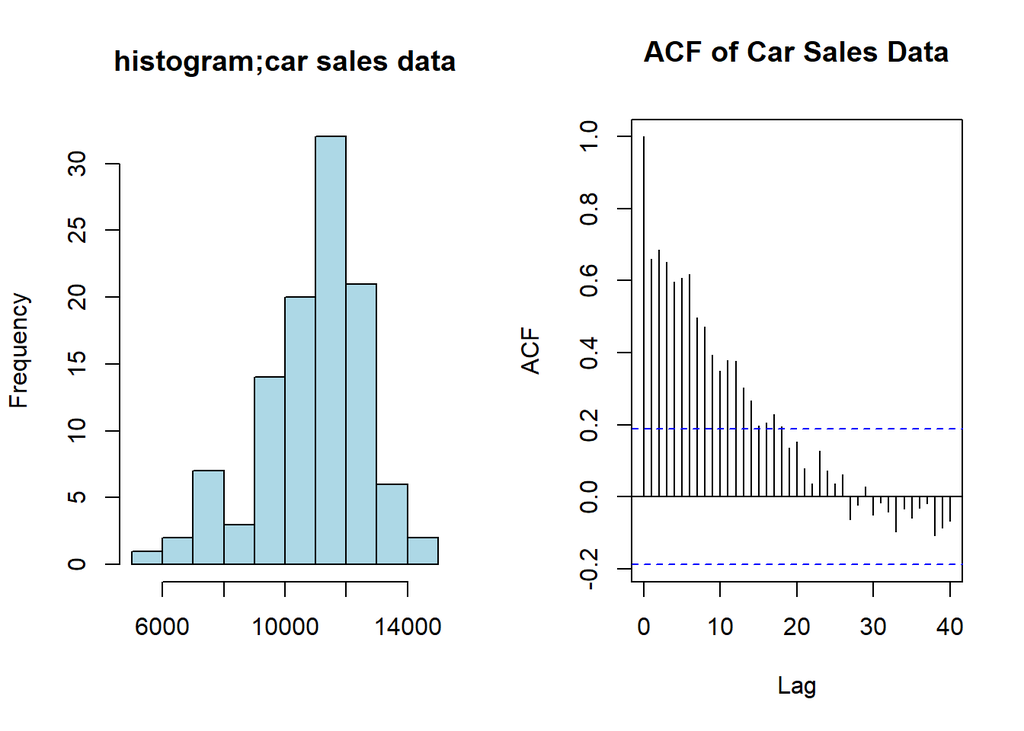

```r
par(mfrow=c(1,2))

# histogram of carstrain
hist(carstrain, col="light blue", xlab="", main="histogram;car sales data")


acf(carstrain, lag.max=40, main="ACF of Car Sales Data")
```

### Box-Cox Transformation

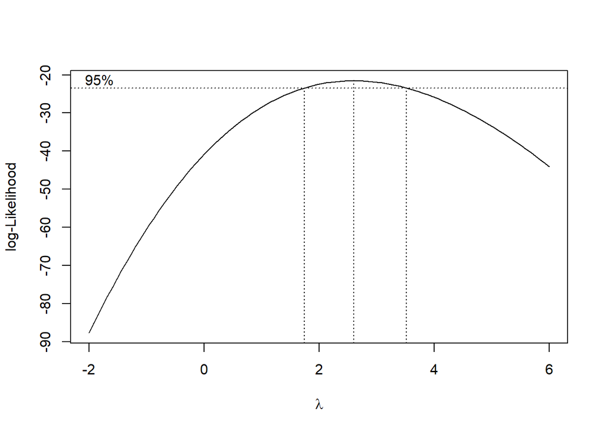

```r
# perform box-cox transformation to make the data normally distributed
bcTransform <- boxcox(carstrain ~ as.numeric(1:length(carstrain)), lambda= seq(-2,6, by = 0.5))
```

```r
bcTransform$x[which(bcTransform$y == max(bcTransform$y))]
```

```
## [1] 2.606061
```

```r
# lambda = 2.606061
lambda = bcTransform$x[which(bcTransform$y == max(bcTransform$y))]
```

Since the data is highly skewed, I tried Box-cox transformation to normalize the data. “BcTransform” command gives value of $\lambda = 2.6061$

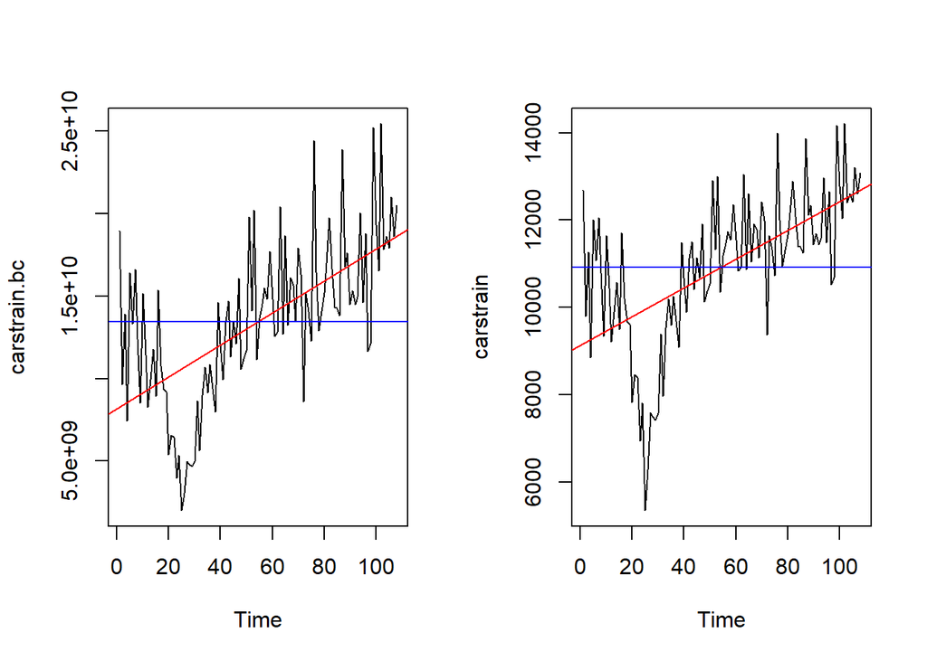

```r
par(mfrow=c(1,2))

lambda = bcTransform$x[which(bcTransform$y == max(bcTransform$y))]

# Box-Cox transformation
carstrain.bc = (1/lambda) * (carstrain^lambda-1)

# plot of U_t after Box-Cox transformation
plot.ts(carstrain.bc)
fit <- lm(carstrain.bc~ as.numeric(1:length(carstrain.bc)))
abline(fit, col="red")
abline(h=mean(carstrain.bc), col="blue")

# plot of U_t before Box-Cox transformation
plot.ts(carstrain)

fit <- lm(carstrain~ as.numeric(1:length(carstrain)))

abline(fit, col="red")
abline(h=mean(carstrain), col="blue")
```

Since the value of $\lambda$ used for Box-Cox transformation was large, overall variance increased, however we could expect to have normalized data and we could see this by plotting a histogram.

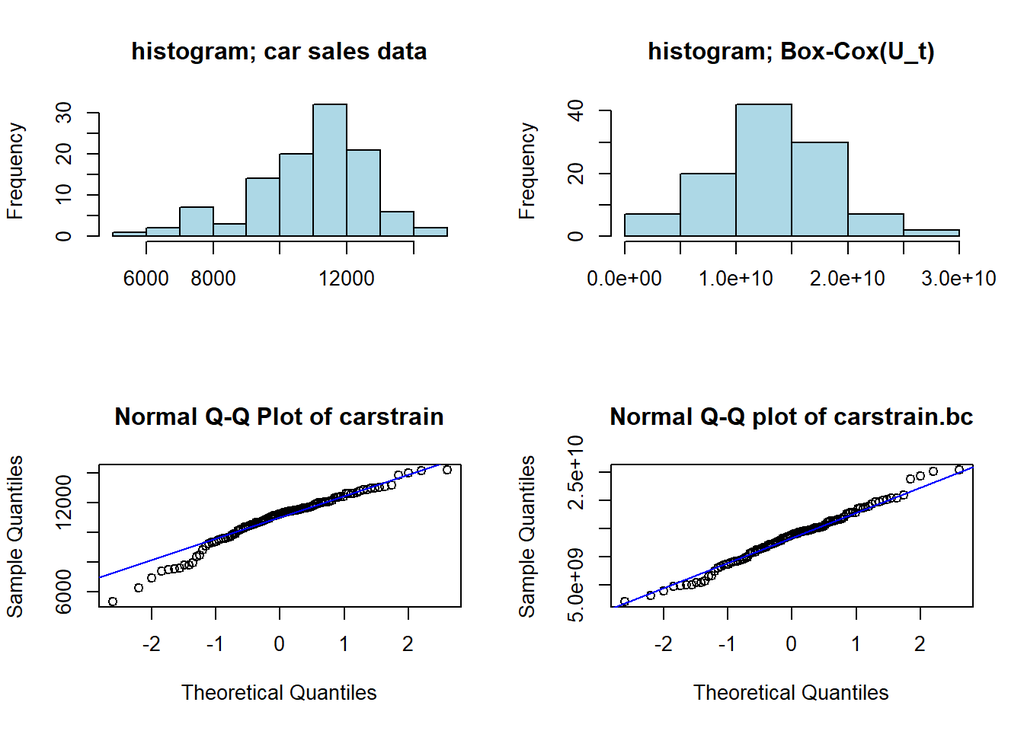

```r
par(mfrow=c(2,2))

hist(carstrain, col="light blue", xlab="", main="histogram; car sales data")
hist(carstrain.bc, col="light blue", xlab="", main="histogram; Box-Cox(U_t)")

qqnorm(carstrain, main = "Normal Q-Q Plot of carstrain")
qqline(carstrain, col = "blue")

qqnorm(carstrain.bc, main = "Normal Q-Q plot of carstrain.bc")
qqline(carstrain.bc, col = "blue")
```

### Make the data stationary(remove trend/seasonality)

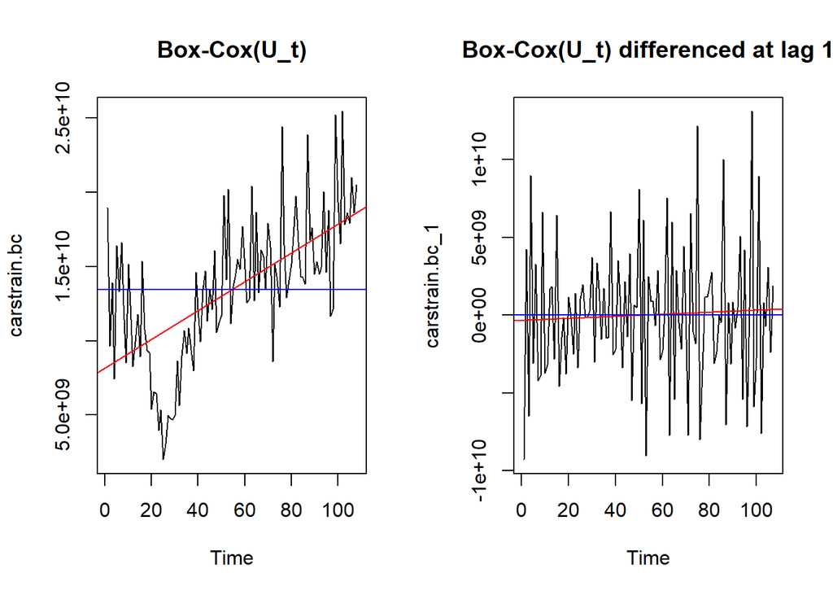

```r
par(mfrow=c(1,2))

carstrain.bc_1 <- diff(carstrain.bc, lag=1)

plot.ts(carstrain.bc, main="Box-Cox(U_t)")
fit <- lm(carstrain.bc ~ as.numeric(1:length(carstrain.bc))); abline(fit, col="red")
abline(h=mean(carstrain.bc), col="blue")

plot.ts(carstrain.bc_1, main="Box-Cox(U_t) differenced at lag 1")
fit <- lm(carstrain.bc_1 ~ as.numeric(1:length(carstrain.bc_1))); abline(fit, col="red")
abline(h=mean(carstrain.bc_1), col="blue")
```

```r
var(carstrain.bc)
```

```
## [1] 2.368118e+19
```

```r
var(carstrain.bc_1)
```

```
## [1] 2.011165e+19
```

Differencing the transformed model at lag 1 removed the trend and the data looks stationary. Also, the variance is lower after removing the trend. However, differencing one more time at lag 1 gives us higher variance that leads to overdifferencing so I didn’t proceed to further differencing.

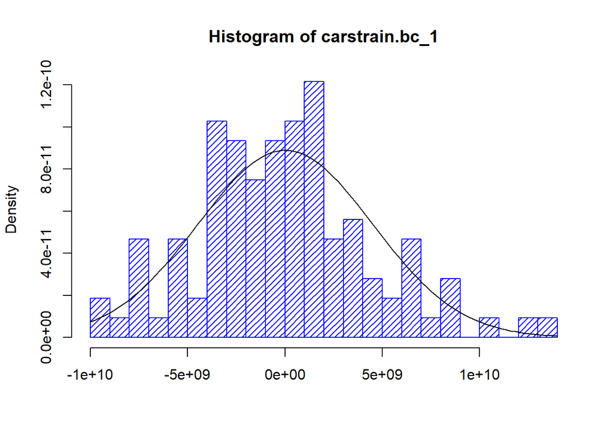

```r
hist(carstrain.bc_1, density=20,breaks=20, col="blue", xlab="", prob=TRUE)
m1 <- mean(carstrain.bc_1)
std1 <- sqrt(var(carstrain.bc_1))
curve(dnorm(x,m1,std1), add=TRUE )
```

histogram of $\nabla_1$Box_Cox$(U_t)$ looks symmetric and normally distributed.

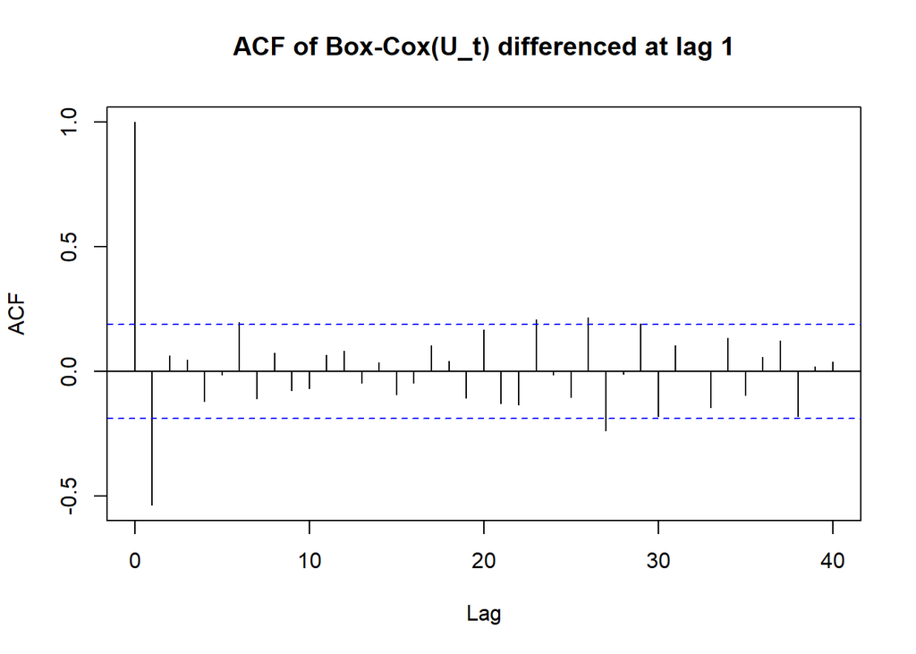

```r
acf(carstrain.bc_1, lag.max=40, main="ACF of Box-Cox(U_t) differenced at lag 1")
```

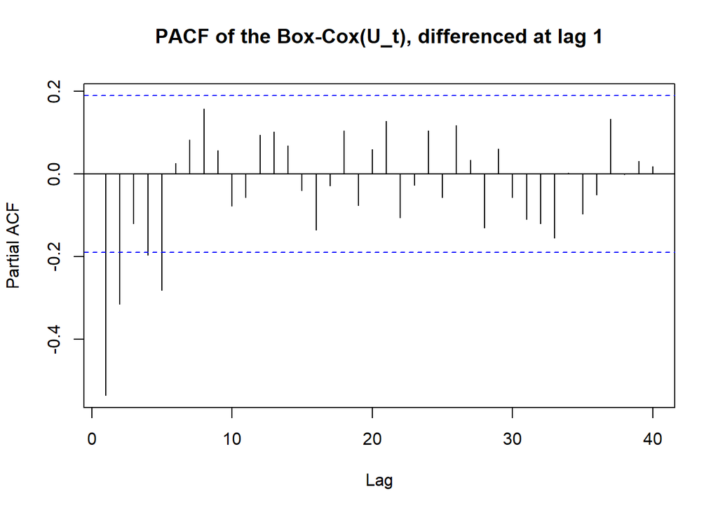

```r
pacf(carstrain.bc_1, lag.max=40, main="PACF of the Box-Cox(U_t), differenced at lag 1")
```

Now, analysis of ACF/PACF could give us what p and q to choose for ARIMA model. There’s a spike outside of the confidence interval at lag 1 from the ACF and PACF suggests $p=5$. Therefore, list of candidate models would be ARIMA model, p ranging from 0 to 5 and q ranging from 0 to 1.

### Possible models

```r
AICc(arima(carstrain.bc, order=c(1,1,0), method= "ML"))
```

```
## [1] 5024.757
```

```r
AICc(arima(carstrain.bc, order=c(2,1,0), method= "ML"))
```

```
## [1] 5014.768
```

```r
AICc(arima(carstrain.bc, order=c(3,1,0), method= "ML"))
```

```
## [1] 5014.144
```

```r
AICc(arima(carstrain.bc, order=c(4,1,0), method= "ML"))
```

```
## [1] 5011.455
```

```r
AICc(arima(carstrain.bc, order=c(5,1,0), method= "ML"))
```

```
## [1] 5002.888
```

```r
AICc(arima(carstrain.bc, order=c(0,1,1), method= "ML"))
```

```
## [1] 5005.797
```

```r
AICc(arima(carstrain.bc, order=c(1,1,1), method= "ML"))
```

```
## [1] 5005.662
```

```r
AICc(arima(carstrain.bc, order=c(2,1,1), method= "ML"))
```

```
## [1] 5007.64
```

```r
AICc(arima(carstrain.bc, order=c(3,1,1), method= "ML"))
```

```
## [1] 5009.673
```

```r
AICc(arima(carstrain.bc, order=c(4,1,1), method= "ML"))
```

```
## [1] 5008.881
```

```r
AICc(arima(carstrain.bc, order=c(5,1,1), method= "ML"))
```

```
## [1] 5005.103
```

By comparing AICcs of possible models, we can narrow down the possible models. ARIMA(5,1,0), ARIMA(5,1,1), and ARIMA(1,1,1) had the lowest AICcs so I’m going to compare these three possible models. Also, I’m going to denote these model A, B, and C respectively.

```r
arima(carstrain.bc, order=c(5,1,0), method= "ML") # model A
```

```
##
## Call:
## arima(x = carstrain.bc, order = c(5, 1, 0), method = "ML")
##
## Coefficients:
##           ar1      ar2      ar3      ar4      ar5
##       -0.8896  -0.6438  -0.5041  -0.4686  -0.3174
## s.e.   0.0934   0.1189   0.1258   0.1181   0.0937
##
## sigma^2 estimated as 1.039e+19:  log likelihood = -2495.15,  aic = 5002.3
```

```r
arima(carstrain.bc, order=c(5,1,1), method= "ML") # model B
```

```
##
## Call:
## arima(x = carstrain.bc, order = c(5, 1, 1), method = "ML")
##
## Coefficients:
##           ar1      ar2      ar3      ar4      ar5     ma1
##       -0.9314  -0.6781  -0.5273  -0.4823  -0.3266  0.0460
## s.e.   0.2639   0.2354   0.1865   0.1434   0.1062  0.2728
##
## sigma^2 estimated as 1.039e+19:  log likelihood = -2495.14,  aic = 5004.27
```

```r
arima(carstrain.bc, order=c(1,1,1), method= "ML") # model C
```

```
##
## Call:
## arima(x = carstrain.bc, order = c(1, 1, 1), method = "ML")
##
## Coefficients:
##           ar1      ma1
##       -0.1793  -0.6841
## s.e.   0.1177   0.0778
##
## sigma^2 estimated as 1.138e+19:  log likelihood = -2499.77,  aic = 5005.55
```

ARIMA(5,1,0), model A in algebraic form would be
$$\nabla_1Box-Cox(U_t) = (1+0.8896B+0.6438B^2+0.5041B^3+0.4686B^4+0.3174B^5)(1-B)X_t = Z_t, \hat{\sigma_z}^2=1.039e+19$$

ARIMA(1,1,1), model C in algebraic form would be
$$\nabla_1Box-Cox(U_t) = (1+0.1793B)(1-B)X_t = (1-0.6841)Z_t, \hat{\sigma_z}^2=1.138e+19$$

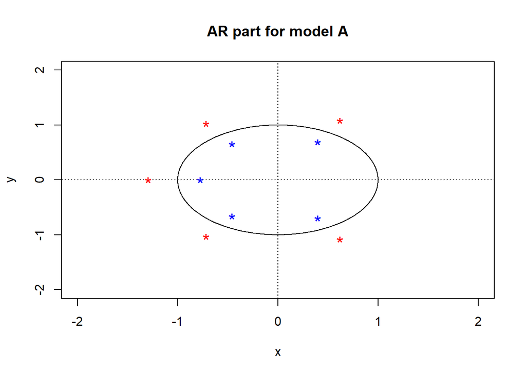

```r
source("plot.roots.R.txt")

# AR part for model A
plot.roots(NULL,polyroot(c(1, 0.8896,0.6438,0.5041,0.4686,0.3174)), main="AR part for model A")
```

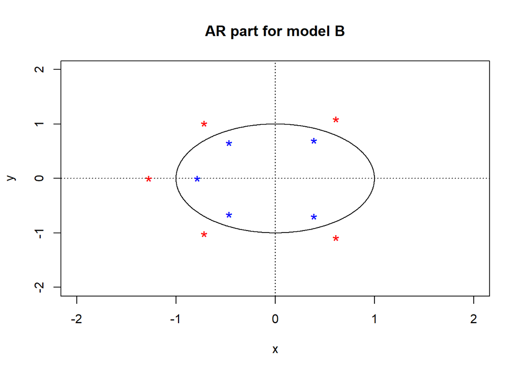

```r
# AR/MA part respectively for model B
plot.roots(NULL,polyroot(c(1, 0.9314,0.6781,0.5273,0.4823,0.3266)), main="AR part for model B")
```

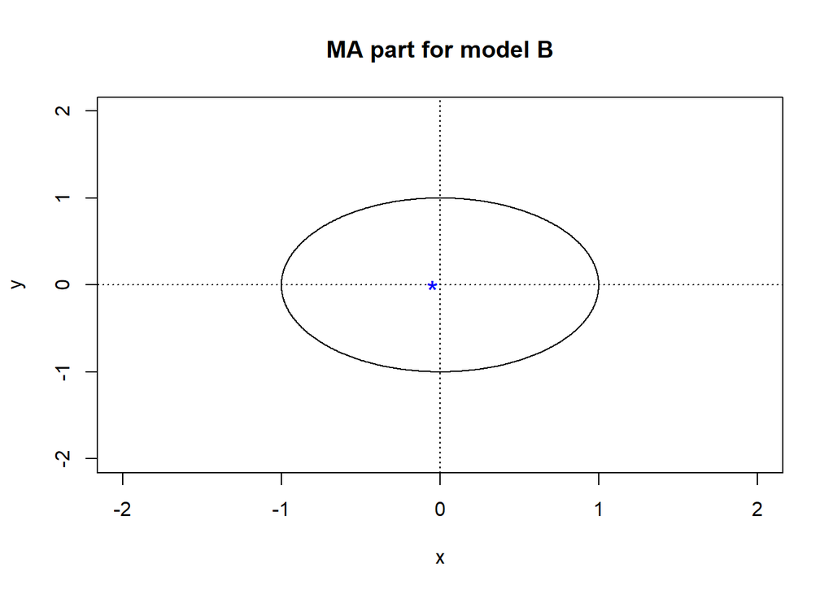

```r
plot.roots(NULL,polyroot(c(1, 0.0460)), main="MA part for model B")
```

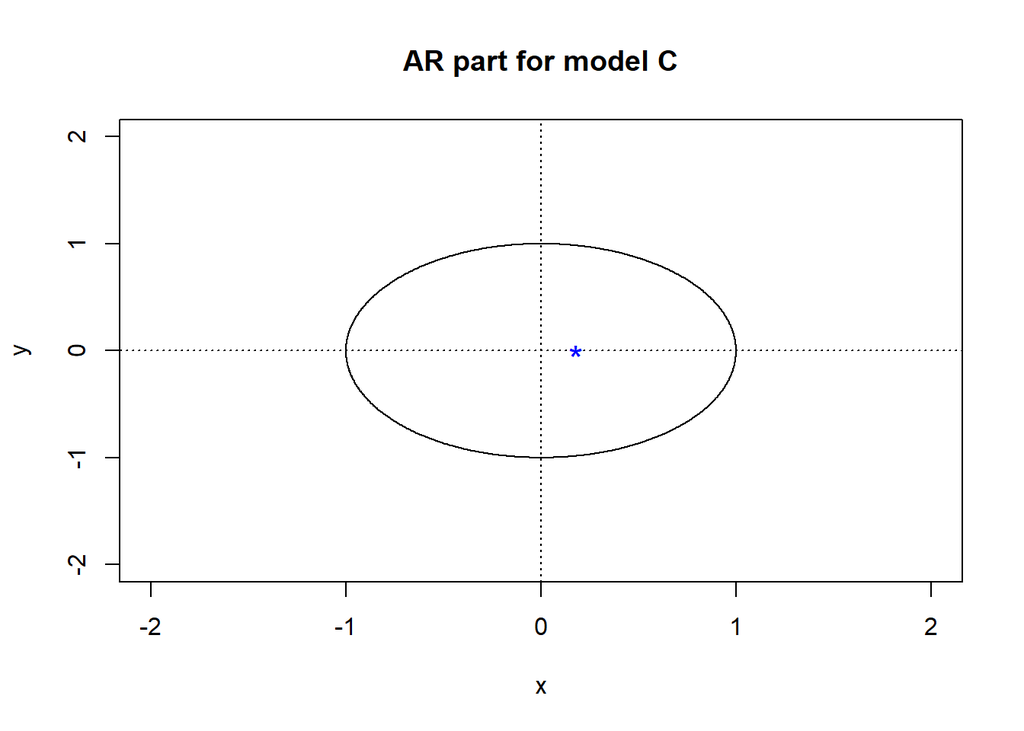

```r
# AR/MA part respectively for model C
plot.roots(NULL,polyroot(c(1, -0.1793)), main="AR part for model C")
```

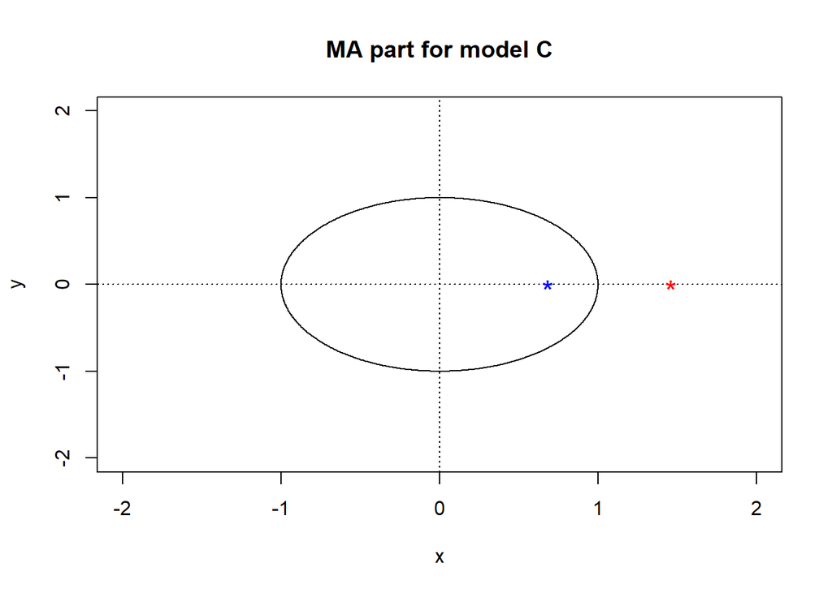

```r
plot.roots(NULL,polyroot(c(1, -0.6841)), main="MA part for model C")
```

All three models are stationary, causal, and invertible since roots of both AR/MA parts for all models lie outside unit circles.

### Model fitting and Diagnostic Checking

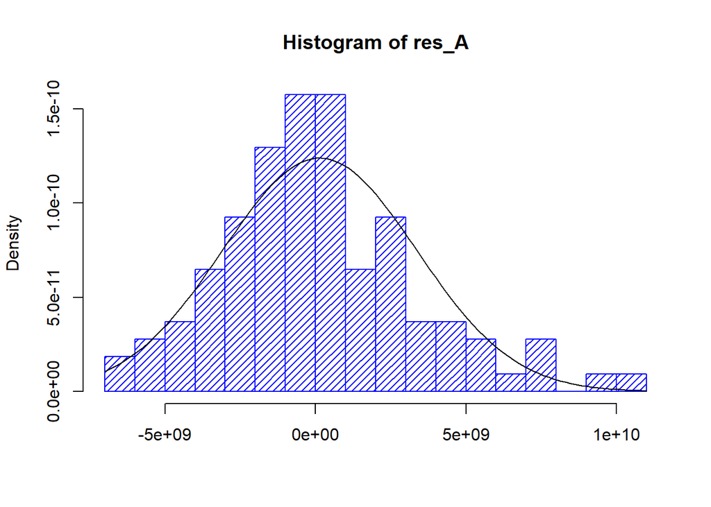

```r
fit1 <- arima(carstrain.bc, order=c(5,1,0), method= "ML")
res1 <- residuals(fit1)
hist(res1,density=20,breaks=20, col="blue", xlab="", prob=TRUE, main = "Histogram of res_A")

m1 <- mean(res1)
std1 <- sqrt(var(res1))
curve( dnorm(x,m1,std1), add=TRUE )
```

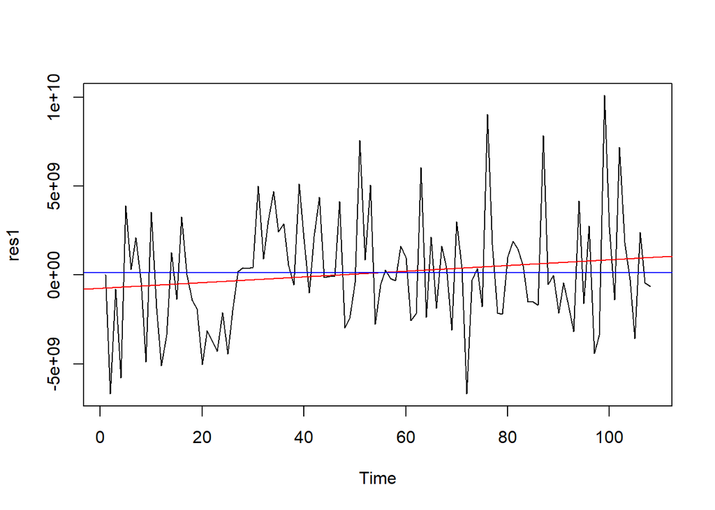

```r
plot.ts(res1)
fitt <- lm(res1 ~ as.numeric(1:length(res1))); abline(fitt, col="red")
abline(h=mean(res1), col="blue")
```

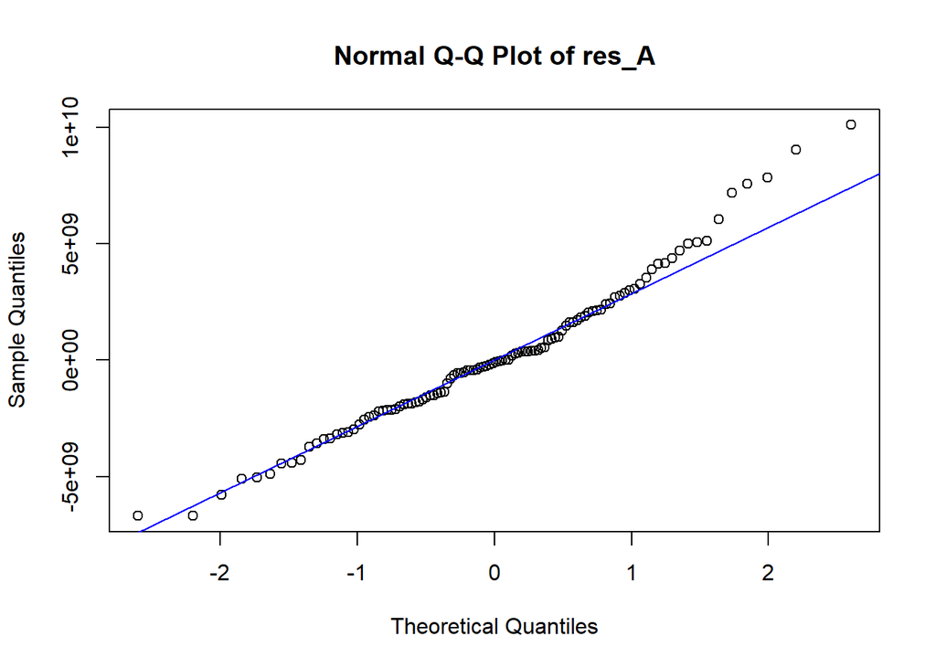

```r
qqnorm(res1,main= "Normal Q-Q Plot of res_A")
qqline(res1,col="blue")
```

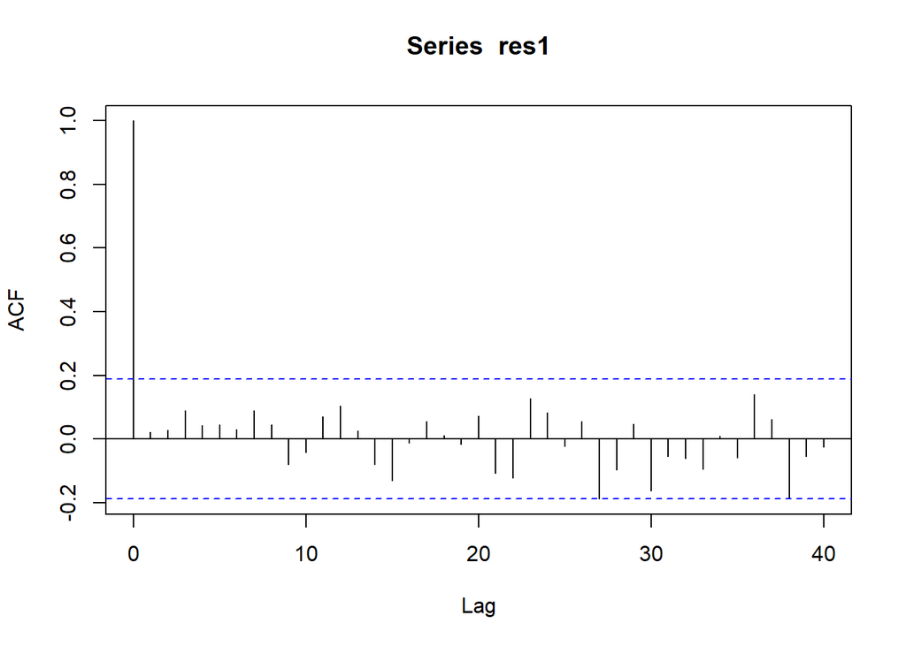

```r
acf(res1, lag.max=40)
```

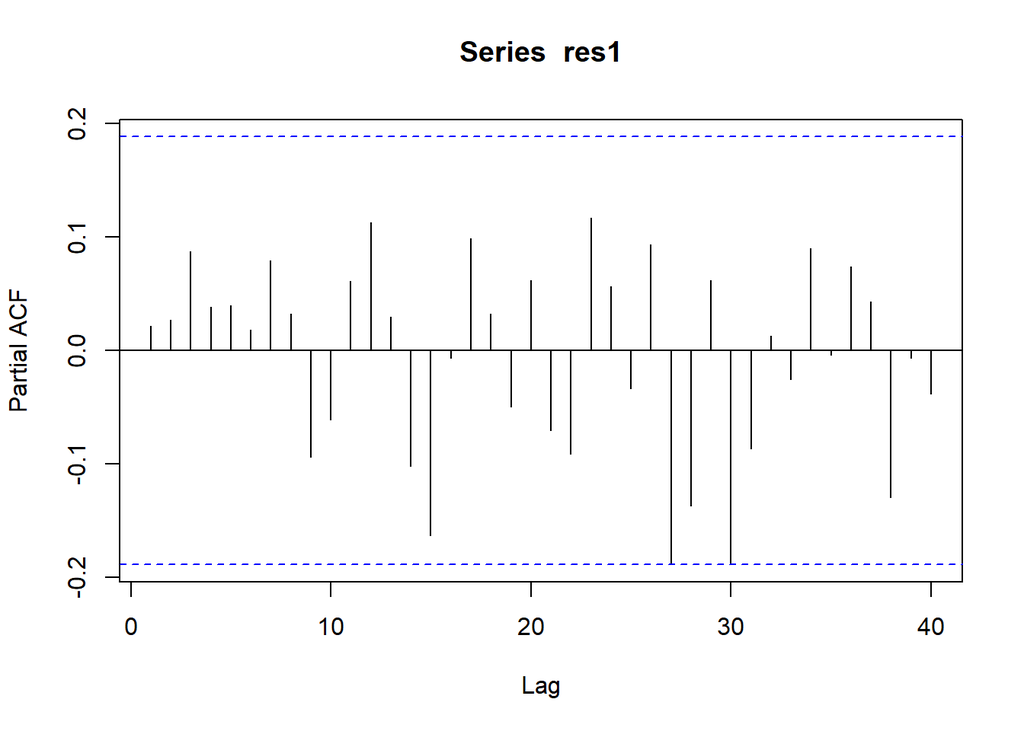

```r
pacf(res1, lag.max=40)
```

```r
shapiro.test(res1)
```

```
##
##  Shapiro-Wilk normality test
##
## data:  res1
## W = 0.97557, p-value = 0.04397
```

```r
Box.test(res1, lag=10, type = c("Box-Pierce"), fitdf=5)
```

```
##
##  Box-Pierce test
##
## data:  res1
## X-squared = 3.4301, df = 5, p-value = 0.634
```

```r
Box.test(res1, lag=10, type = c("Ljung-Box"), fitdf=5)
```

```
##
##  Box-Ljung test
##
## data:  res1
## X-squared = 3.7057, df = 5, p-value = 0.5925
```

```r
Box.test(res1^2, lag=10, type = c("Ljung-Box"), fitdf=0)
```

```
##
##  Box-Ljung test
##
## data:  res1^2
## X-squared = 6.2428, df = 10, p-value = 0.7945
```

```r
ar(res1, aic = TRUE, order.max = NULL, method = c("yule-walker"))
```

```
##
## Call:
## ar(x = res1, aic = TRUE, order.max = NULL, method = c("yule-walker"))
##
##
## Order selected 0  sigma^2 estimated as  1.037e+19
```

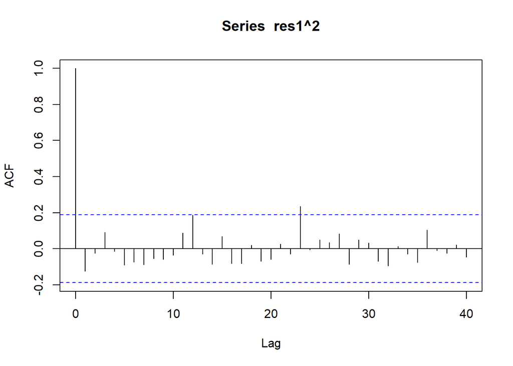

```r
acf(res1^2, lag.max=40)
```

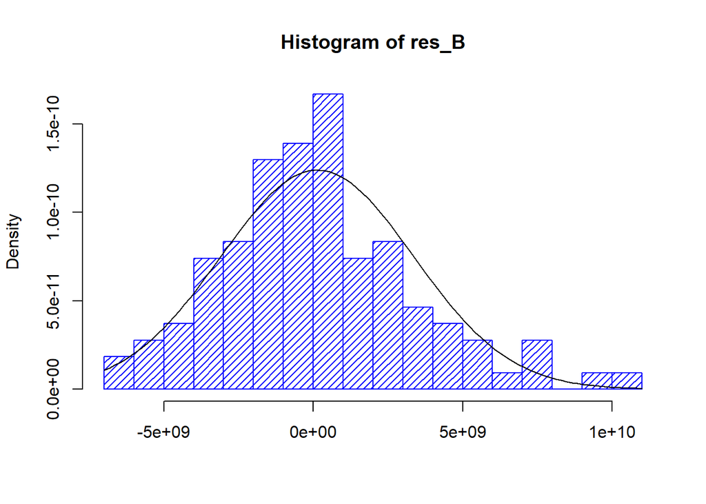

```r
fit2 <- arima(carstrain.bc, order=c(5,1,1), method= "ML")
res2 <- residuals(fit2)
hist(res2,density=20,breaks=20, col="blue", xlab="", prob=TRUE, main="Histogram of res_B")

m2 <- mean(res2)
std2 <- sqrt(var(res2))
curve( dnorm(x,m2,std2), add=TRUE )
```

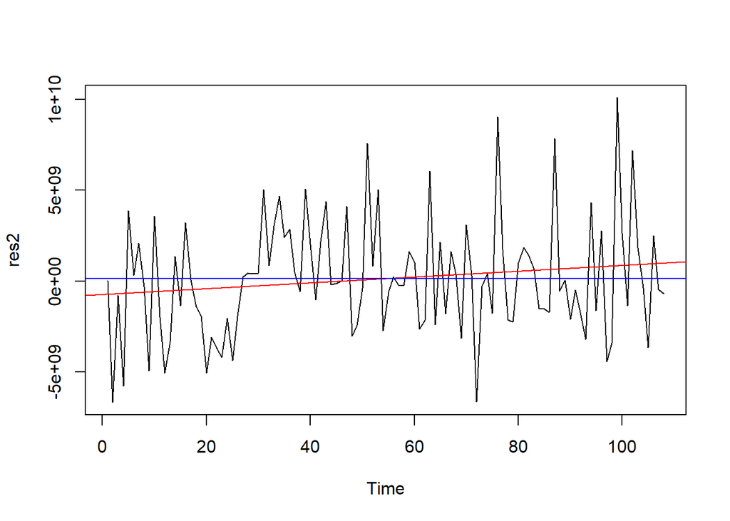

```r
plot.ts(res2)
fitt <- lm(res2 ~ as.numeric(1:length(res2))); abline(fitt, col="red")
abline(h=mean(res2), col="blue")
```

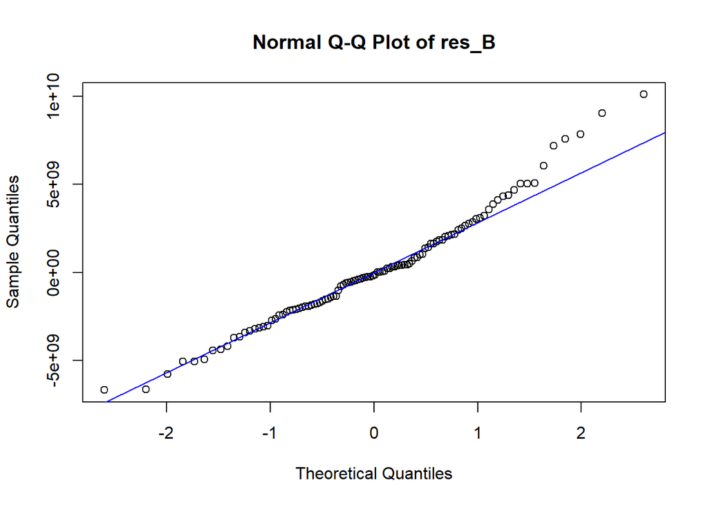

```r
qqnorm(res2,main= "Normal Q-Q Plot of res_B")
qqline(res2,col="blue")
```

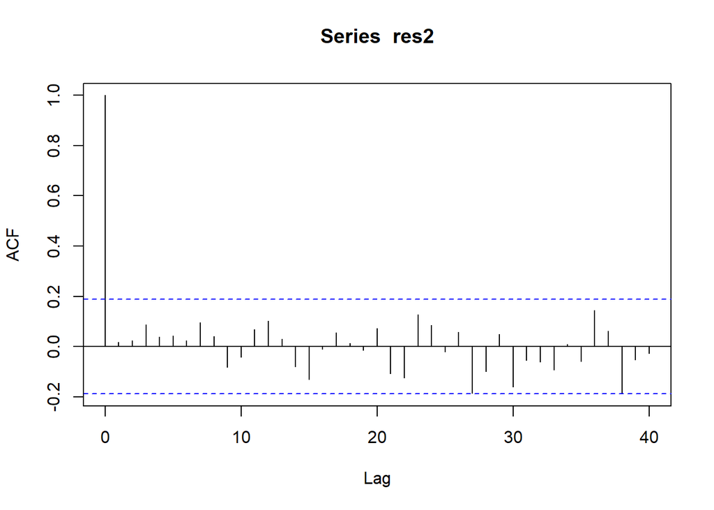

```r
acf(res2, lag.max=40)
```

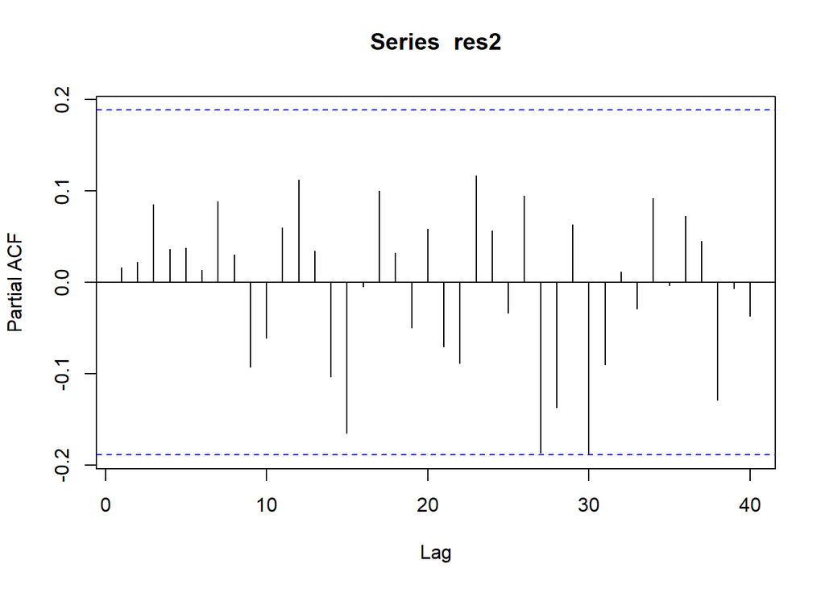

```r
pacf(res2, lag.max=40)
```

```r
shapiro.test(res2)
```

```
##
##  Shapiro-Wilk normality test
##
## data:  res2
## W = 0.97585, p-value = 0.04635
```

```r
Box.test(res2, lag=10, type = c("Box-Pierce"), fitdf=6)
```

```
##
##  Box-Pierce test
##
## data:  res2
## X-squared = 3.3765, df = 4, p-value = 0.4969
```

```r
Box.test(res2, lag=10, type = c("Ljung-Box"), fitdf=6)
```

```
##
##  Box-Ljung test
##
## data:  res2
## X-squared = 3.6536, df = 4, p-value = 0.4549
```

```r
Box.test(res2^2, lag=10, type = c("Ljung-Box"), fitdf=0)
```

```
##
##  Box-Ljung test
##
## data:  res2^2
## X-squared = 6.0149, df = 10, p-value = 0.814
```

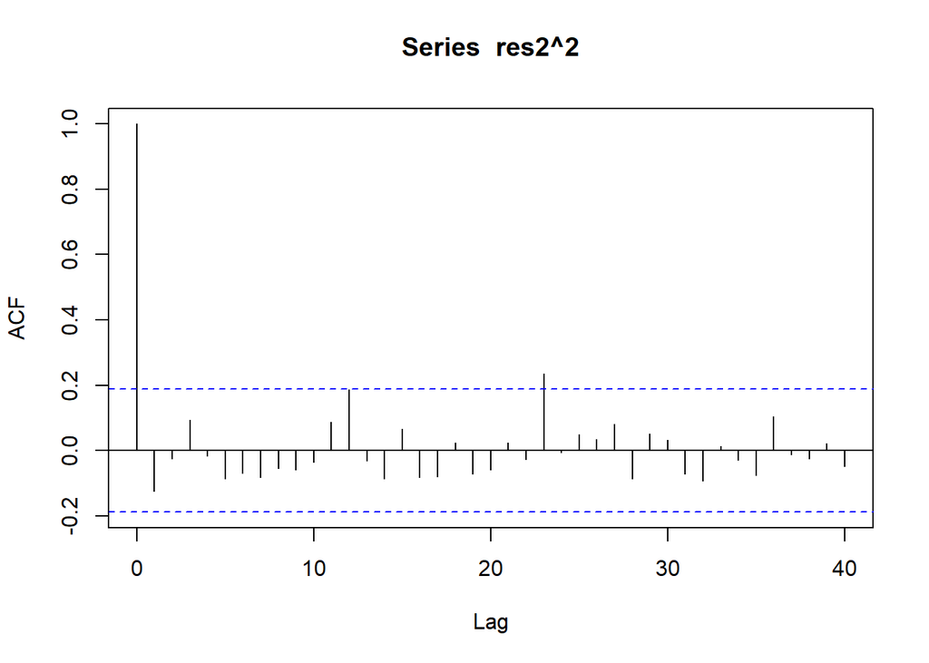

```r
acf(res2^2, lag.max=40)
```

```r
ar(res2, aic = TRUE, order.max = NULL, method = c("yule-walker"))
```

```
##
## Call:
## ar(x = res2, aic = TRUE, order.max = NULL, method = c("yule-walker"))
##
##
## Order selected 0  sigma^2 estimated as  1.037e+19
```

Model B also looks good, there’s a slight trend but it’s negligible. Also, histogram and Q-Q plot shows that the residual of model B is normally distributed. All acf and pacf of residuals are within confidence intervals and can be counted as zeros as well. Just like model A, model B passes all the tests but Shapiro-Wilk normality test, having p-value(0.04635) less than 0.05.

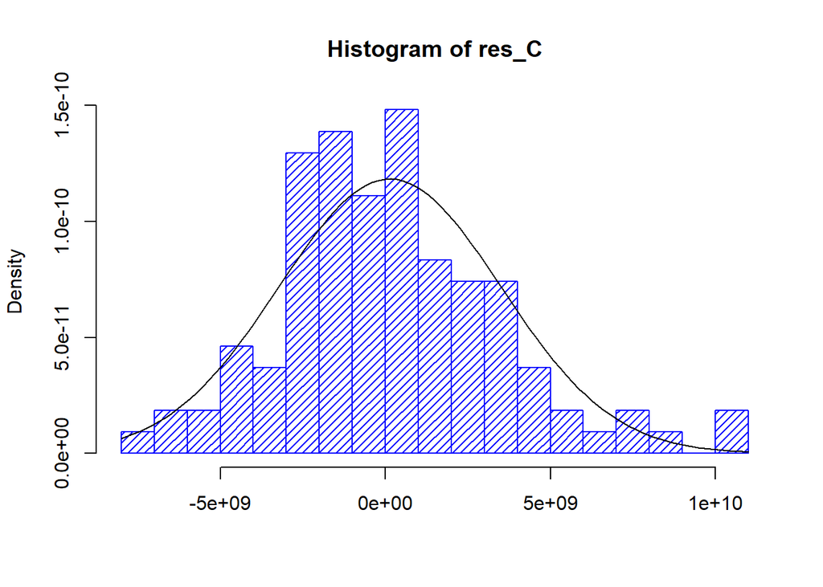

```r
fit3 <- arima(carstrain.bc, order=c(1,1,1), method= "ML")
res3 <- residuals(fit3)
hist(res3,density=20,breaks=20, col="blue", xlab="", prob=TRUE, main="Histogram of res_C")

m3 <- mean(res3)
std3 <- sqrt(var(res3))
curve( dnorm(x,m3,std3), add=TRUE )
```

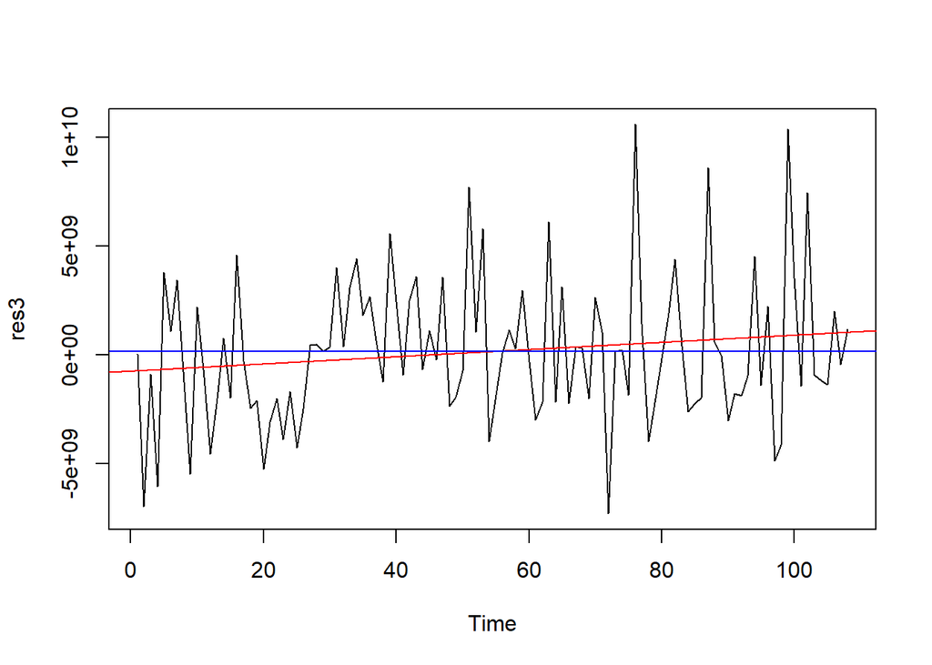

```r
plot.ts(res3)
fitt <- lm(res3 ~ as.numeric(1:length(res3))); abline(fitt, col="red")
abline(h=mean(res3), col="blue")
```